# INN_Learner_Notebook_Full_code

#### Run with SMOTE

```python
# check version number
import imblearn
print(imblearn.__version__)
```

```
0.11.0
```

**Use SMOTE**

The [challenge of working with imbalanced datasets](https://machinelearningmastery.com/smote-oversampling-for-imbalanced-classification/) is that most machine learning techniques will ignore, and in turn have poor performance on, the minority class, although typically it is performance on the minority class that is most important.

```python
X_train.shape
```

```
(6400, 11)
```

```python
# summarize class distribution
counter = Counter(y_train)
print(counter)
y_train.shape
```

```
Counter({0: 5096, 1: 1304})
```

```
(6400,)
```

The original paper on SMOTE suggested combining SMOTE with random undersampling of the majority class.

```python
# define pipeline
over = SMOTE(random_state=42)
under = RandomUnderSampler(random_state=42)
steps = [('o', over), ('u', under)]
pipeline = Pipeline(steps=steps)

# transform the dataset
X_train_res, y_train_res = pipeline.fit_resample(X_train, y_train)
```

```python
# summarize the new class distribution
counter = Counter(y_train_res)
print(counter)
y_train_res.shape
```

```
Counter({0: 5096, 1: 5096})
```

```
(10192,)
```

Apply balanced data using SMOTE as the training data and execute the same model. Use the same validation data

```python
# clears the current Keras session, resetting all layers and models previously created, freeing up memory and resources.
tf.keras.backend.clear_session()
```

```python
#Initializing the neural network
model = Sequential()
model.add(Dense(14,activation="relu",input_dim=X_train.shape[1]))
model.add(Dense(7,activation="relu"))
model.add(Dense(1,activation="sigmoid"))
```

```python
# Create optimizer with default learning rate
# Compile the model
optimizer = tf.keras.optimizers.SGD()    # defining SGD as the optimizer to be used
model.compile(optimizer=optimizer,loss='binary_crossentropy',metrics=['accuracy'])
```

```python
model.summary()
```

```
Model: "sequential"
_________________________________________________________________
 Layer (type)                Output Shape              Param #
=================================================================
 dense (Dense)               (None, 14)                168

 dense_1 (Dense)             (None, 7)                 105

 dense_2 (Dense)             (None, 1)                 8

=================================================================
Total params: 281 (1.10 KB)
Trainable params: 281 (1.10 KB)
Non-trainable params: 0 (0.00 Byte)
_________________________________________________________________
```

```python
start = time.time()
history = model.fit(X_train_res, y_train_res, validation_data=(X_valid,y_valid) , batch_size=batch_size, epochs=epochs, class_weight=cw_dict)
end=time.time()
```

```python
print("Time taken in seconds ",end-start)
```

```
Time taken in seconds  4.89260458946228
```

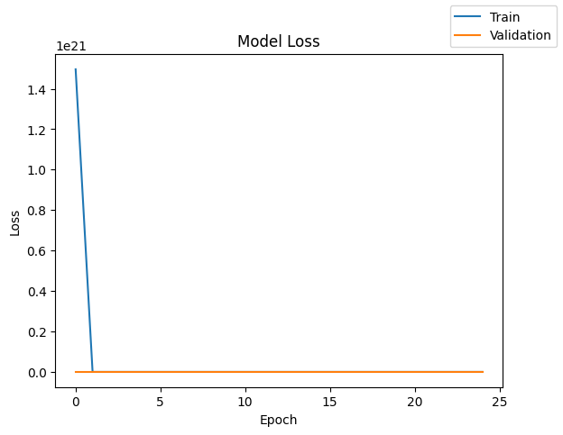

```python
plot(history,'loss')
```

```python
model_5_train_perf = model_performance_classification(model, X_train_res, y_train_res)
model_5_train_perf
```

|  | Accuracy | Recall | Precision | F1 Score |
| --- | --- | --- | --- | --- |
| 0 | 0.50 | 0.50 | 0.25 | 0.33 |

```python
model_5_valid_perf = model_performance_classification(model, X_valid, y_valid)
model_5_valid_perf
```

|  | Accuracy | Recall | Precision | F1 Score |
| --- | --- | --- | --- | --- |
| 0 | 0.20 | 0.20 | 0.04 | 0.07 |

**Observation**

This model fails to learn.